# Personal calender management

Anthony Davidson

2020-07-28

# Overview

I find a challenging aspect of academic research is assoicated with organising both my work and personal time management. Now that I am attempting to work with the skills obtained during my PhD I have so many different projects running at/in different levels of development and collaboration. This repository is a draft approach to my time management using `tidyPipes` workflow.

# Introduction

> NOTE: This is my first attempt to apply my `tidyPipes` workflow (Figure above) to my project management and integrate this into my normal workflow.

Generally, this work is focused on writing the scripts to automate the intergration between emails, PhD timeline and other projects. To do this we need to import datasets and modify the structure of these imputs to match the information needed to contruct a timeline of tasks and objectives.

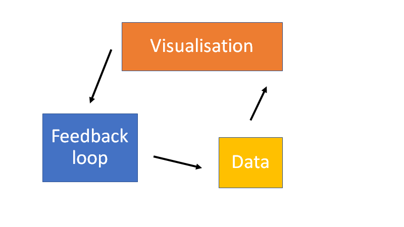

SEE tidyPipes MANUAL for general concept and approach. This repository contains example data and scripts needed to visualise and communicate multiple different projects including:

- `flatttingRMDstlyle/` (a repository for documentign and recording reproducible reports for my flatting arrangements).
- `PhDplanningRMDstyle/` (the documentation and reporting for the final 6months of my PhD).

```r
library(readr)
library(dplyr)
```

```r
library(ggplot2)
library(scales)
library(lubridate)
```

# Methods

Generally the concept is to create a baseline dataset of information and then extend this using `dataspice` to create a tidy format of data that can then be modelled and visualised using the `tidyverse` suite of tools.

```r
library(lubridate)
# glimpse(datBASE)
# dt <- data.frame(mon = c(10, 4), day = c(10, 4), year = c(2017, 2018))

# with(dt, ymd(paste(year, mon, day, sep = "-")))
```

[output not shown]

```r
### to correct ggplot subset
datBASE1 <- datBASE  %>%
    dplyr::select(startDate,month, year, milestone, status, shortName, project) %>%
                 mutate(date = as.Date(startDate, "%d/%m/%y"))
# ,
#                        month = as.numeric(as.character(month)),
#                        year = as.numeric(year),
#                        milestone = as.factor(milestone),
#                        status = as.factor(status))
# glimpse(datBASE1)
# df$date <- with(df, ymd(sprintf('%04d%02d%02d', year, month, 1)))
df <- datBASE1

# library(lubridate)
# dt <- data.frame(mon = c(10, 4), day = c(10, 4), year = c(2017, 2018))
# with(dt, ymd(paste(year, mon, day, sep = "-")))
```

[output not shown]

```r
# datBASE1$date <- with(datBASE1, ymd(sprintf('%04d%02d%02d', year, month, 1)))
df <- df[with(df, order(date)), ]
# head(df)
text_offset <- 0.05
```

## Data setup

```r
library(knitr)
```

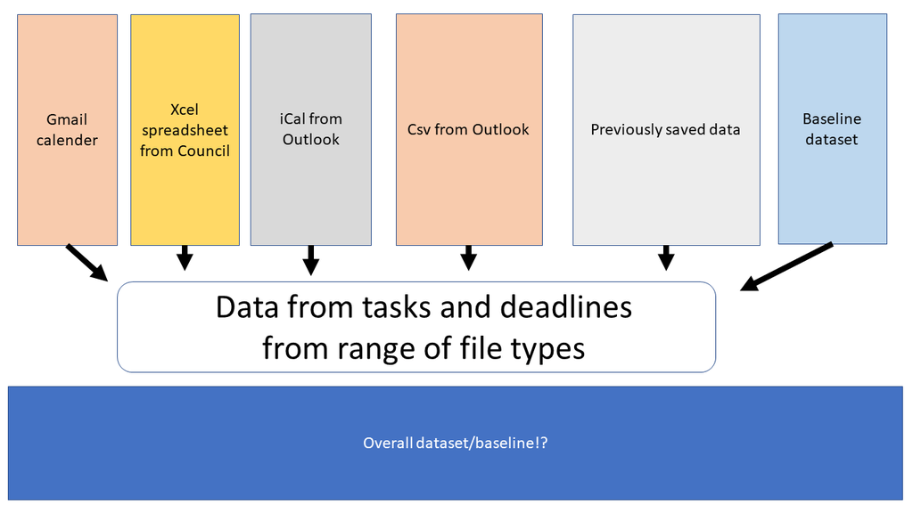

```r
knitr::include_graphics(path = "./img/TidyPipes-calenderJUL2020v2.png")
```

There are multiple difference sources of information for this calendar. To be able to keep this upto date and current I need to write scripts for each data-source to my database of events (here). These are the following importing scripts:

- Timeline figures:
  - Past
  - Future
- Actions and milestones

Overall this is time series data. A good general tutorial for this sort of data is here on youtube. There are several ways to visualise this data, below are two selected bits of code that do this. Overall there are two generalised datasets that may be helpful to other individuals for each project or combination of projects (for the APR for example). The data for this collection of tasks associated with timelines and targets. The baseline dataset is found in the `.xlsx` file named “baseline-dataset-calender.xlsx”. This is the base file I have been adding information to when I change the overall structure of the calendar projects.

### Manual data

To begin with I have collated and restructured the avaliable data from downloaded `.ics` data as a csv and the UCSRC council calendar. This sorted data was orginally saved as “baseline-dataset-calender.xlsx” but as I couldnt get the xcel package to work nicely I converted each project dataset into a csv file stored in the `./data/` folder.

### Baseline

```r
source("./R/importDATAscript.R", echo = FALSE)
DT::datatable(head(datBASE))
```

|  | eventCode | shortName | month | startDate | finishDate | startTime | endTime | description | project | individualsNEEDED | week | year | milestone | status | PreCovidDATE | Tasks | Notes | attachment | cost |
| --- | --- | --- | --- | --- | --- | --- | --- | --- | --- | --- | --- | --- | --- | --- | --- | --- | --- | --- | --- |
| 1 | phd20200701001 | FullPhDleft | july | 1/07/2020 | 31/12/2020 | 09:00:00 | 15:00:00 | Just the full length of time I think I will need to finish my PhD project | PhD | Anthony |  | 2020 | PhDmilestone 1 | On Target | 31/07/2020 | Comments on reproducibility | Comment to nature draft attached |  |  |
| 2 | phd20200701013 | ScholarShip_end | june | 7/07/2020 | 9/07/2020 |  |  | When my scholarship finished | PhD | Anthony |  | 2020 | PhDmilestone 2 | Complete | 2/11/2019 | finish beech draft | Currently with Richard |  |  |
| 3 | phd20200701002 | MethodsPhD | august | 1/08/2020 | 3/08/2020 | 09:00:00 | 15:00:00 | The core methods papers in the final drafts ready for submission. Reproducibility framework (tidyPipes) and the invasive nz mamals database. | PhD | Anthony |  | 2020 | PhDmilestone 3 | On Target | 5/11/2019 | 2020 draft MPD paper1 simulation and/or case study results? | This progress on this is underway |  |  |
| 4 | phd20200701003 | DiscussionPhDleft | september | 1/09/2020 | 6/03/2020 | 09:00:00 | 15:00:00 | Building the wrapping publication on the application of the invasive species database for community groups and researchers. | PhD | Anthony |  | 2020 | PhDmilestone 4 | On Target |  | Working on this in conjunction with first and final thesis chapters around the value of computational reproducibility at a national scale like PFNZ2050 |  |  |  |
| 5 | phd20200701004 | tidyPipesPhD | october | 23/07/2020 | 8/10/2019 | 09:00:00 | 15:00:00 |  | PhD | Anthony |  | 2020 | PhDmilestone 5 | On Target |  | draft MPD paper2 case study results? |  |  |  |
| 6 | phd20200701005 | natureMANUSCRIPT | july | 1/11/2020 | 11/05/2019 | 09:00:00 | 15:00:00 | Rejected: submit 300 word comment. | PhD | Anthony |  | 2020 | PhDmilestone 6 | Complete | 6/11/2019 |  |  |  |  |

```r
#incorperate milestones
# source(here::here("./vignettes/milestonesfromdataframe.Rmd"), local = TRUE,opts_knit(rmarkdown.html_vignette.check_title = FALSE))
# vignette("./vignettes/milestones-from-dataframe.html")
```

### `.xlsx`

These are excel workbooks. For now this is very simple and works with the current version of excel files (2020). Each “sheet” of the excel file contains a single projects information. This is then converted to a csv file when needed. In the future each project will have its own file that can be added to or modified in a shiny interactive web app.

```r
#excel read

#number of sheets in project currently


## Saved as csv's and imported as so below...
```

> A key aspect of these R scripts is the date format. This has been challenging to work with but currently I have the following notes on the transformation of the date/time data from excel and manually (with csv file below).

### `.csv`

Generally the data can be imported as a csv, or other form.

```r
library(readr)
emailsCalender1 <- read_csv("data/raw_data/anuemails.CSV")
#str(emailsCalender1)
```

### `.iCal` data

```r
#this currently online
```

### Other data

# Visualisation

Generally the concept is to create a baseline dataset of information and then extend this using `dataspice` to create a tidy format of data that can then be modelled and visualised using the `tidyverse` suite of tools.

*Creating timeline charts in R (Generating Timeline charts: Blog online)*

### Action tasks

Table by the group of project month or something else???

#### Table 1

```r
table(datBASE1$month, datBASE1$project)
```

```
##
##             council finances invert PhD src
##   january         0        6      0   0   0
##   february        1        4      4   5   8
##   march           1        3      0   1   4
##   april           0        3      8   3   4
##   may             0        8      0   1   4
##   june            0        9      0   0   0
##   july            0        3      0   0   0
##   august          0        0      0   2   4
##   september       1        0      0   1   6
##   october         0        3      0   1  11
##   november        0        0      0   0   0
##   december        0        0      0   0   0
```

#### Table 2

```r
table(datBASE1$month, datBASE1$project, datBASE1$status)
```

```
## , ,  = At Risk
##
##
##             council finances invert PhD src
##   january         0        0      0   0   0
##   february        0        0      0   3   0
##   march           0        0      0   0   0
##   april           0        0      0   1   0
##   may             0        0      0   0   0
##   june            0        0      0   0   0
##   july            0        0      0   0   0
##   august          0        0      0   0   0
##   september       0        0      0   0   0
##   october         0        0      0   0   0
##   november        0        0      0   0   0
##   december        0        0      0   0   0
##
## , ,  = Complete
##
##
##             council finances invert PhD src
##   january         0        0      0   0   0
##   february        0        0      0   0   0
##   march           0        0      0   0   0
##   april           0        0      3   1   4
##   may             0        0      0   1   4
##   june            0        0      0   0   0
##   july            0        0      0   0   0
##   august          0        0      0   2   0
##   september       0        0      0   0   0
##   october         0        0      0   0   0
##   november        0        0      0   0   0
##   december        0        0      0   0   0
##
## , ,  = Critical
##
##
##             council finances invert PhD src
##   january         0        0      0   0   0
##   february        0        0      0   0   0
```

[output cut: 29 more lines]

```
##
##
##             council finances invert PhD src
##   january         0        0      0   0   0
##   february        1        0      4   1   8
##   march           1        0      0   0   4
##   april           0        0      4   1   0
##   may             0        0      0   0   0
##   june            0        0      0   0   0
##   july            0        0      0   0   0
##   august          0        0      0   0   4
##   september       1        0      0   1   6
##   october         0        0      0   1  11
##   november        0        0      0   0   0
##   december        0        0      0   0   0
```

To do this I have created a calendar for each key project/impact/aspect of short-term timeline, objectives, as well as, my career and life projection. To begin with I need to create timelines and other project goals under covid19. I have put this into a single dataset called `dat` here.

These figures can be generated using `ggplot` and other `tidyverse` approaches due to the implantation of the `dataspice` packages above. We will use *ggplot* function from *ggplot2* package to generate timeline charts. The following plots can be created using layers to detail charts.

## `ggplot2`

### Milestones timeline

“Coverting a dataframe into a timeline”

### Factoring

```r
#factoring
status_levels <- c("Complete", "On Target", "At Risk", "Critical")

status_colors <- c("#0070C0", "#00B050", "#FFC000", "#C00000")

df$status <- factor(df$status, levels=status_levels, ordered=TRUE)
```

### Direction

```r
library(lubridate)
df <- readr::read_csv(here::here('./data/milestones.csv'))
df$date <- with(df, ymd(sprintf('%04d%02d%02d', year, month, 1)))
#direction
positions <- c(0.5, -0.5, 1.0, -1.0, 1.5, -1.5)
directions <- c(1, -1)

line_pos <- data.frame(
    "date"=unique(df$date),
    "position"=rep(positions, length.out=length(unique(df$date))),
    "direction"=rep(directions, length.out=length(unique(df$date)))
)

df <- merge(x=df, y=line_pos, by="date", all = TRUE)
df <- df[with(df, order(date, status)), ]

df$month_count <- ave(df$date==df$date, df$date, FUN=cumsum)
text_offset <- 0.2

df$text_position <- (df$month_count * text_offset * df$direction) + df$position
head(df)
```

|  | date | month | year | milestone | status | position | direction | month_count | text_position |
| --- | --- | --- | --- | --- | --- | --- | --- | --- | --- |
| 1 | 2017-06-01 | 6 | 2017 | Milestone 1 | Complete | 0.5 | 1 | 1 | 0.7 |
| 2 | 2017-07-01 | 7 | 2017 | Milestone 2 | Complete | -0.5 | -1 | 1 | -0.7 |
| 3 | 2017-10-01 | 10 | 2017 | Milestone 3 | Complete | 1.0 | 1 | 1 | 1.2 |
| 4 | 2017-12-01 | 12 | 2017 | Milestone 4 | Complete | -1.0 | -1 | 1 | -1.2 |
| 5 | 2018-01-01 | 1 | 2018 | Milestone 5 | Complete | 1.5 | 1 | 1 | 1.7 |
| 6 | 2018-01-01 | 1 | 2018 | Milestone 6 | Complete | 1.5 | 1 | 2 | 1.9 |

### Counts

```r
text_offset <- 0.2

df$month_count <- ave(df$date==df$date, df$date, FUN=cumsum)
df$text_position <- (df$month_count * text_offset * df$direction) + df$position
head(df)
```

|  | date | month | year | milestone | status | position | direction | month_count | text_position |
| --- | --- | --- | --- | --- | --- | --- | --- | --- | --- |
| 1 | 2017-06-01 | 6 | 2017 | Milestone 1 | Complete | 0.5 | 1 | 1 | 0.7 |
| 2 | 2017-07-01 | 7 | 2017 | Milestone 2 | Complete | -0.5 | -1 | 1 | -0.7 |
| 3 | 2017-10-01 | 10 | 2017 | Milestone 3 | Complete | 1.0 | 1 | 1 | 1.2 |
| 4 | 2017-12-01 | 12 | 2017 | Milestone 4 | Complete | -1.0 | -1 | 1 | -1.2 |
| 5 | 2018-01-01 | 1 | 2018 | Milestone 5 | Complete | 1.5 | 1 | 1 | 1.7 |
| 6 | 2018-01-01 | 1 | 2018 | Milestone 6 | Complete | 1.5 | 1 | 2 | 1.9 |

### Buffering times

```r
month_buffer <- 2

month_date_range <- seq(min(df$date) - months(month_buffer), max(df$date) + months(month_buffer), by='month')
month_format <- format(month_date_range, '%b')
month_df <- data.frame(month_date_range, month_format)
```

### December/January only

```r
year_date_range <- seq(min(df$date) - months(month_buffer), max(df$date) + months(month_buffer), by='year')
year_date_range <- as.Date(
    intersect(
        ceiling_date(year_date_range, unit="year"),
        floor_date(year_date_range, unit="year")
    ),  origin = "1970-01-01"
)
year_format <- format(year_date_range, '%Y')
year_df <- data.frame(year_date_range, year_format)
```

### Interactivity

Shiny….

# Feedback loop

To create the feedback loop (to get information back from supervisors) I have began to develop a interactive shiny app within the same structure as the baseline dataset so that there is limited coding needed to create the tidypipes “cycle” of community engagement.

```r
library(knitr)
```

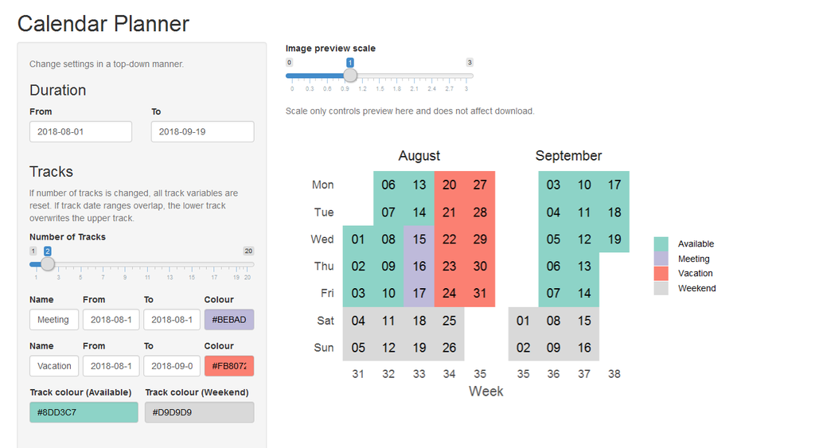

```r
knitr::include_graphics(path = "./img/preview.png")
```

As computational work takes over our regular management of time over the tradional hard copy “diary”. I like this because important information can not be left in the “local cafe” however as I have used “gmail”, “outlook” and there suites of applications and tools for calenders I have muddled everything up and missed appointments etc.

There is alot of my development work in this section because I have attempted to combine these two packages in a way to document all the council emails and other work that I have undertaken as part of the `COVID19` pandemic in Australia.

To try and counter this I have developed a `tidypipes` workflow for my tasks, projects and other collarorations. See presentation here.

# Overall outputs

## Timeline

Timeline charts can be used in a lot of applications like tracking equipment or a process status changes, resource availability & scheduling, project timelines, documenting start and end times of events. The beauty of ggplot2 package is that the code can be easily customized, and more details can be added to the plots.

## Calendars

Calender information….’

## Plot simple

```r
# names(datBASE)
# datBASE$project

# ggplot(datBASE1, aes(x = date, y = shortName)) +
#   geom_point() +
#   facet_wrap(~project, scales = "free")
```

## Final plot option 1

```r
# timeline_plot <-filter(df, status != "NA" & project == "PhD") %>%
#   ggplot(aes(x=date,y=0, col=status, label=milestone)) +
#   labs(col="Milestones")+
#   # scale_color_manual(values=status_colors, labels=status_levels, drop = FALSE)+
#   theme_classic() +
#   geom_hline(yintercept=0, color = "black", size=0.3) #+
  # facet_wrap(~project)

# # Plot vertical segment lines for milestones
# timeline_plot<-timeline_plot+geom_segment(data=df[df$month_count == 1,], aes(y=position,yend=0,xend=date), color='black', size=0.2)
#
# # Plot scatter points at zero and date
# timeline_plot<-timeline_plot+geom_point(aes(y=0), size=3)
#
# # Don't show axes, appropriately position legend
# timeline_plot<-timeline_plot+theme(axis.line.y=element_blank(),
#                  axis.text.y=element_blank(),
#                  axis.title.x=element_blank(),
#                  axis.title.y=element_blank(),
#                  axis.ticks.y=element_blank(),
#                  axis.text.x =element_blank(),
#                  axis.ticks.x =element_blank(),
#                  axis.line.x =element_blank(),
#                  legend.position = "bottom"
#                 )
#
# # Show text for each month
# timeline_plot<-timeline_plot+geom_text(data=month_df, aes(x=month_date_range,y=-0.1,label=month_format),size=2.5,vjust=0.5, color='black', angle=90)
#
# # Show year text
# timeline_plot<-timeline_plot+geom_text(data=year_df, aes(x=year_date_range,y=-0.2,label=year_format, fontface="bold"),size=2.5, color='black')

# Show text for each milestone
timeline_plot<-timeline_plot+geom_text(aes(y=text_position,label=shortName),size=4)
timeline_plot
```

[output not shown]

## Timeline

One of the tricky bits about timelines is the format of the date and time of each event. This is different for each event so therefore we have four columns to incorporate this information in the following from for this repository and database. This will also mean that some of the information in other formats will have to be converted into these dimension and any other elements defined in each dataset I am combining to make a overall timeline.

By integrating these stage with some `dataspice` code/approach’s allows for me to generate metadata from each sheet of the excel file quickly using R. Here are the steps to do this.

```r
#dataspice from github
library(dataspice)

#each project needs to be imported and then saved as csv in raw_data file to document variable names etc correctly into the json dataset.
# raw_data <-
project2 <- readxl::read_excel("./data/raw_data/Sem two planning.xlsx", sheet = 4)
project2
```

| eventCode | shortName | month | startDate | finishDate | startTime | endTime | description | src | ucX | week |
| --- | --- | --- | --- | --- | --- | --- | --- | --- | --- | --- |
| scr20200701001 | WorldRefDay | june | 20/06/2020 | 20/06/2020 | 1899-12-31 09:00:00 | 1899-12-31 15:00:00 | World Refugee Day | NA | NA | NA |
| scr20200701002 | Oweek | july | 44039 | 44043 | 1899-12-31 09:00:00 | 1899-12-31 22:00:00 | O week for semester two | NA | NA | NA |
| scr20200701003 | ReasonStatement | august | 44044 | NA | 1899-12-31 09:00:00 | 1899-12-31 15:00:00 | Statement of reasons due (late Aug) | NA | NA | NA |
| scr20200701004 | SSAFsurvey | august | 44044 | NA | 1899-12-31 09:00:00 | 1899-12-31 15:00:00 | SSAF Survey | NA | NA | NA |
| scr20200701005 | TownHall2 | august | 44044 | NA | 1899-12-31 09:00:00 | 1899-12-31 15:00:00 | Town HAll | NA | NA | NA |
| scr20200701006 | openDay | august | 44044 | NA | 1899-12-31 09:00:00 | 1899-12-31 15:00:00 | Open Day 22nd | NA | NA | NA |
| scr20200701007 | nic21st | august | 44044 | NA |  | 1899-12-31 15:00:00 | Nicks 21st Birthday | NA | NA | NA |
| scr20200701008 | SSAFbids | september | 44075 | NA | 1899-12-31 09:00:00 | 1899-12-31 15:00:00 | SSAF Bids Due | NA | NA | NA |
| scr20200701009 | Grad | september | 44075 | NA | 1899-12-31 09:00:00 | 1899-12-31 15:00:00 | Graduation | NA | NA | NA |
| scr20200701010 | SSAFFunds | september | 44075 | NA |  |  | SSAF Committeess | NA | NA | NA |

[output cut: 12 more lines]

```r
#date
data_actions <- readxl::read_excel("./data/raw_data/Sem two planning.xlsx", sheet = 1)
```

```
## * `` -> ...7
## * `` -> ...8
## * `` -> ...9
## * `` -> ...10
## * `` -> ...11
## * ...
```

```r
data_names <- readxl::read_excel("./data/raw_data/Sem two planning.xlsx", sheet = 3)
#time

#location
```

#### Past Outcomes

### Action timeline

These sources of data are combined for my general timeline below. These summarised actions are also the flagged tasks from outlook calendar to catch up with this information but this can be automated in the future.

```r
# DT::datatable(emailsCalender1)
## handmade data
DT::datatable(data_actions)
```

|  | Day | action | month | person | notes | eventCode | ...7 | ...8 | ...9 | ...10 | ...11 | ...12 | ...13 | ...14 |
| --- | --- | --- | --- | --- | --- | --- | --- | --- | --- | --- | --- | --- | --- | --- |
| 1 | 1 |  | june |  |  |  |  |  |  |  |  |  |  |  |
| 2 | 2 |  | june |  |  |  |  |  |  |  |  |  |  |  |
| 3 | 3 | Academic Board (Majid/Josh) | june | Majid; Josh |  |  |  |  |  |  |  |  |  |  |
| 4 | 4 | Academic Integrity Mtg (Lola/Hamish/Nick) Student Equity &amp; Advisory Group (TBD) | june | Lola; Hamish; Nick |  |  |  |  |  |  |  |  |  | z |
| 5 | 5 |  | june |  |  |  |  |  |  |  |  |  |  |  |
| 6 | 6 |  | june |  |  |  |  |  |  |  |  |  |  |  |
| 7 | 7 |  | june |  |  |  |  |  |  |  |  |  |  |  |
| 8 | 8 |  | june |  |  |  |  |  |  |  |  |  |  |  |
| 9 | 9 |  | june |  |  |  |  |  |  |  |  |  |  |  |
| 10 | 10 |  | june |  |  |  |  |  |  |  |  |  |  |  |

[output cut: 238 more lines]

```r
# there should be an actions...
data_actions
```

| Day | action | month | person | notes | eventCode | ...7 | ...8 | ...9 | ...10 | ...11 | ...12 | ...13 | ...14 |
| --- | --- | --- | --- | --- | --- | --- | --- | --- | --- | --- | --- | --- | --- |
| 1 | NA | june | NA | NA | NA | NA | NA | NA | NA | NA | NA | NA | NA |
| 2 | NA | june | NA | NA | NA | NA | NA | NA | NA | NA | NA | NA | NA |
| 3 | Academic Board (Majid/Josh) | june | Majid; Josh | NA | NA | NA | NA | NA | NA | NA | NA | NA | NA |
| 4 | Academic Integrity Mtg (Lola/Hamish/Nick) Student Equity & Advisory Group (TBD) | june | Lola; Hamish; Nick | NA | NA | NA | NA | NA | NA | NA | NA | NA | z |
| 5 | NA | june | NA | NA | NA | NA | NA | NA | NA | NA | NA | NA | NA |
| 6 | NA | june | NA | NA | NA | NA | NA | NA | NA | NA | NA | NA | NA |
| 7 | NA | june | NA | NA | NA | NA | NA | NA | NA | NA | NA | NA | NA |
| 8 | NA | june | NA | NA | NA | NA | NA | NA | NA | NA | NA | NA | NA |
| 9 | NA | june | NA | NA | NA | NA | NA | NA | NA | NA | NA | NA | NA |
| 10 | NA | june | NA | NA | NA | NA | NA | NA | NA | NA | NA | NA | NA |

[output cut: 238 more lines]

### Future targets

#### Plot current data

```r
library(ggplot2)
library(scales)
library(lubridate)

source("./R/importDATAscript.R")
# Now let’s load in some data
#milestones is the demo data
#actions is my data

df <- readr::read_csv('./data/milestones.csv')
df
```

| month | year | milestone | status |
| --- | --- | --- | --- |
| 6 | 2017 | Milestone 1 | Complete |
| 7 | 2017 | Milestone 2 | Complete |
| 10 | 2017 | Milestone 3 | Complete |
| 12 | 2017 | Milestone 4 | Complete |
| 1 | 2018 | Milestone 5 | Complete |
| 1 | 2018 | Milestone 6 | Complete |
| 2 | 2018 | Milestone 7 | Complete |
| 5 | 2018 | Milestone 8 | Complete |
| 6 | 2018 | Milestone 9 | On Target |
| 6 | 2018 | Milestone 10 | On Target |

[output cut: 12 more lines]

#### Subset dataframe

to correct ggplot subset

```r
df$date <- with(df, ymd(sprintf('%04d%02d%02d', year, month, 1)))
df <- df[with(df, order(date)), ]
head(df)
```

| month | year | milestone | status | date |
| --- | --- | --- | --- | --- |
| 6 | 2017 | Milestone 1 | Complete | 2017-06-01 |
| 7 | 2017 | Milestone 2 | Complete | 2017-07-01 |
| 10 | 2017 | Milestone 3 | Complete | 2017-10-01 |
| 12 | 2017 | Milestone 4 | Complete | 2017-12-01 |
| 1 | 2018 | Milestone 5 | Complete | 2018-01-01 |
| 1 | 2018 | Milestone 6 | Complete | 2018-01-01 |

```r
text_offset <- 0.05

#factoring
status_levels <- c("Complete", "On Target", "At Risk", "Critical")

status_colors <- c("#0070C0", "#00B050", "#FFC000", "#C00000")

df$status <- factor(df$status, levels=status_levels, ordered=TRUE)

#direction
positions <- c(0.5, -0.5, 1.0, -1.0, 1.5, -1.5)
directions <- c(1, -1)

line_pos <- data.frame(
    "date"=unique(df$date),
    "position"=rep(positions, length.out=length(unique(df$date))),
    "direction"=rep(directions, length.out=length(unique(df$date)))
)

df <- merge(x=df, y=line_pos, by="date", all = TRUE)
df <- df[with(df, order(date, status)), ]

df$month_count <- ave(df$date==df$date, df$date, FUN=cumsum)
df$text_position <- (df$month_count * text_offset * df$direction) + df$position
head(df)
```

|  | date | month | year | milestone | status | position | direction | month_count | text_position |
| --- | --- | --- | --- | --- | --- | --- | --- | --- | --- |
| 1 | 2017-06-01 | 6 | 2017 | Milestone 1 | Complete | 0.5 | 1 | 1 | 0.55 |
| 2 | 2017-07-01 | 7 | 2017 | Milestone 2 | Complete | -0.5 | -1 | 1 | -0.55 |
| 3 | 2017-10-01 | 10 | 2017 | Milestone 3 | Complete | 1.0 | 1 | 1 | 1.05 |
| 4 | 2017-12-01 | 12 | 2017 | Milestone 4 | Complete | -1.0 | -1 | 1 | -1.05 |
| 5 | 2018-01-01 | 1 | 2018 | Milestone 5 | Complete | 1.5 | 1 | 1 | 1.55 |
| 6 | 2018-01-01 | 1 | 2018 | Milestone 6 | Complete | 1.5 | 1 | 2 | 1.60 |

#### Counts

```r
text_offset <- 0.05

df$month_count <- ave(df$date==df$date, df$date, FUN=cumsum)
df$text_position <- (df$month_count * text_offset * df$direction) + df$position
head(df)
```

|  | date | month | year | milestone | status | position | direction | month_count | text_position |
| --- | --- | --- | --- | --- | --- | --- | --- | --- | --- |
| 1 | 2017-06-01 | 6 | 2017 | Milestone 1 | Complete | 0.5 | 1 | 1 | 0.55 |
| 2 | 2017-07-01 | 7 | 2017 | Milestone 2 | Complete | -0.5 | -1 | 1 | -0.55 |
| 3 | 2017-10-01 | 10 | 2017 | Milestone 3 | Complete | 1.0 | 1 | 1 | 1.05 |
| 4 | 2017-12-01 | 12 | 2017 | Milestone 4 | Complete | -1.0 | -1 | 1 | -1.05 |
| 5 | 2018-01-01 | 1 | 2018 | Milestone 5 | Complete | 1.5 | 1 | 1 | 1.55 |
| 6 | 2018-01-01 | 1 | 2018 | Milestone 6 | Complete | 1.5 | 1 | 2 | 1.60 |

#### Buffering times

```r
month_buffer <- 2

month_date_range <- seq(min(df$date) - months(month_buffer), max(df$date) + months(month_buffer), by='month')
month_format <- format(month_date_range, '%b')
month_df <- data.frame(month_date_range, month_format)
```

### December/January only

```r
year_date_range <- seq(min(df$date) - months(month_buffer), max(df$date) + months(month_buffer), by='year')
year_date_range <- as.Date(
    intersect(
        ceiling_date(year_date_range, unit="year"),
        floor_date(year_date_range, unit="year")
    ),  origin = "1970-01-01"
)
year_format <- format(year_date_range, '%Y')
year_df <- data.frame(year_date_range, year_format)
```

#### Plot simple

[figure not shown]

```r
# names(datBASE)
# datBASE$project

ggplot(datBASE, aes(x = startDate, y = shortName)) +
  geom_point() +
  facet_wrap(~project)
```

#### Final plot option 1

See Ben Alex Keen’s blog with the following output:

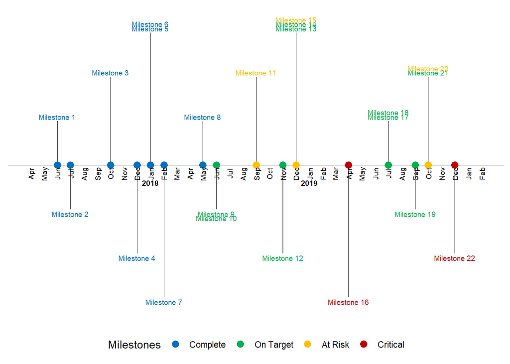

```r
timeline_plot<-ggplot(df,aes(x=date,y=0, col=status, label=milestone))
timeline_plot<-timeline_plot+labs(col="Milestones")
timeline_plot<-timeline_plot+scale_color_manual(values=status_colors, labels=status_levels, drop = FALSE)
timeline_plot<-timeline_plot+theme_classic()

# Plot horizontal black line for timeline
timeline_plot<-timeline_plot+geom_hline(yintercept=0,
                color = "black", size=0.3)

# Plot vertical segment lines for milestones
timeline_plot<-timeline_plot+geom_segment(data=df[df$month_count == 1,], aes(y=position,yend=0,xend=date), color='black', size=0.2)

# Plot scatter points at zero and date
timeline_plot<-timeline_plot+geom_point(aes(y=0), size=3)

# Don't show axes, appropriately position legend
timeline_plot<-timeline_plot+theme(axis.line.y=element_blank(),
                 axis.text.y=element_blank(),
                 axis.title.x=element_blank(),
                 axis.title.y=element_blank(),
                 axis.ticks.y=element_blank(),
                 axis.text.x =element_blank(),
                 axis.ticks.x =element_blank(),
                 axis.line.x =element_blank(),
                 legend.position = "bottom"
                )

# Show text for each month
timeline_plot<-timeline_plot+geom_text(data=month_df, aes(x=month_date_range,y=-0.1,label=month_format),size=2.5,vjust=0.5, color='black', angle=90)
# Show year text
timeline_plot<-timeline_plot+geom_text(data=year_df, aes(x=year_date_range,y=-0.2,label=year_format, fontface="bold"),size=2.5, color='black')
# Show text for each milestone
timeline_plot<-timeline_plot+geom_text(aes(y=text_position,label=milestone),size=2.5)
print(timeline_plot)
```

### Individual projects

Each of my tasks come from a collection of overall projects I collaborate on and develop code with on timeframes that range from monthly to undefined. The current projects I have integrated into my timeline are:

### PhD

```r
project1 <- readxl::read_excel("./data/raw_data/Sem two planning.xlsx", sheet = 3)

DT::datatable(head(project1))
```

|  | eventCode | shortName | month | startDate | finishDate | startTime | endTime | description | src | ucX | week |
| --- | --- | --- | --- | --- | --- | --- | --- | --- | --- | --- | --- |
| 1 | phd20200701001 | FullPhDleft | july | 2020-07-01T00:00:00Z | 2020-12-31T00:00:00Z | 1899-12-31T09:00:00Z | 1899-12-31T15:00:00Z | Just the full length of time I need to finish my PhD project |  |  |  |
| 2 | phd20200701013 | ScholarShip_end | june | 2020-07-07T00:00:00Z | 2020-07-09T00:00:00Z |  |  |  |  |  |  |
| 3 | phd20200701002 | MethodsPhD | august | 2020-08-01T00:00:00Z | 2020-08-03T00:00:00Z | 1899-12-31T09:00:00Z | 1899-12-31T15:00:00Z |  |  |  |  |
| 4 | phd20200701003 | DiscussionPhDleft | september | 2020-09-01T00:00:00Z | 2020-03-06T00:00:00Z | 1899-12-31T09:00:00Z | 1899-12-31T15:00:00Z |  |  |  |  |
| 5 | phd20200701004 | tidyPipesPhD | october | 2020-10-01T00:00:00Z | 2019-10-08T00:00:00Z | 1899-12-31T09:00:00Z | 1899-12-31T15:00:00Z |  |  |  |  |
| 6 | phd20200701005 | natureleft | november | 2020-11-01T00:00:00Z | 2019-05-11T00:00:00Z | 1899-12-31T09:00:00Z | 1899-12-31T15:00:00Z |  |  |  |  |

[figure not shown]

#### Introduction

#### Methods

#### Conclusion

#### Discussion

### Previous achievements and tasks

### Council tasks

```r
project2 <- readxl::read_excel("./data/raw_data/Sem two planning.xlsx", sheet = 4)

DT::datatable(head(project2))
```

|  | eventCode | shortName | month | startDate | finishDate | startTime | endTime | description | src | ucX | week |
| --- | --- | --- | --- | --- | --- | --- | --- | --- | --- | --- | --- |
| 1 | scr20200701001 | WorldRefDay | june | 20/06/2020 | 20/06/2020 | 1899-12-31T09:00:00Z | 1899-12-31T15:00:00Z | World Refugee Day |  |  |  |
| 2 | scr20200701002 | Oweek | july | 44039 | 44043 | 1899-12-31T09:00:00Z | 1899-12-31T22:00:00Z | O week for semester two |  |  |  |
| 3 | scr20200701003 | ReasonStatement | august | 44044 |  | 1899-12-31T09:00:00Z | 1899-12-31T15:00:00Z | Statement of reasons due (late Aug) |  |  |  |
| 4 | scr20200701004 | SSAFsurvey | august | 44044 |  | 1899-12-31T09:00:00Z | 1899-12-31T15:00:00Z | SSAF Survey |  |  |  |
| 5 | scr20200701005 | TownHall2 | august | 44044 |  | 1899-12-31T09:00:00Z | 1899-12-31T15:00:00Z | Town HAll |  |  |  |
| 6 | scr20200701006 | openDay | august | 44044 |  | 1899-12-31T09:00:00Z | 1899-12-31T15:00:00Z | Open Day 22nd |  |  |  |

#### UC-Council

Generally it is regarded that there will be about a week (40hrs) of background reading and investigation before each council meeting. Under covid19 conditions I think this may be much greater.

```r
dataCouncil <- readxl::read_excel("./data/raw_data/Sem two planning.xlsx", sheet = 3)

DT::datatable(head(dataCouncil))
```

|  | eventCode | shortName | month | startDate | finishDate | startTime | endTime | description | src | ucX | week |
| --- | --- | --- | --- | --- | --- | --- | --- | --- | --- | --- | --- |
| 1 | phd20200701001 | FullPhDleft | july | 2020-07-01T00:00:00Z | 2020-12-31T00:00:00Z | 1899-12-31T09:00:00Z | 1899-12-31T15:00:00Z | Just the full length of time I need to finish my PhD project |  |  |  |
| 2 | phd20200701013 | ScholarShip_end | june | 2020-07-07T00:00:00Z | 2020-07-09T00:00:00Z |  |  |  |  |  |  |
| 3 | phd20200701002 | MethodsPhD | august | 2020-08-01T00:00:00Z | 2020-08-03T00:00:00Z | 1899-12-31T09:00:00Z | 1899-12-31T15:00:00Z |  |  |  |  |
| 4 | phd20200701003 | DiscussionPhDleft | september | 2020-09-01T00:00:00Z | 2020-03-06T00:00:00Z | 1899-12-31T09:00:00Z | 1899-12-31T15:00:00Z |  |  |  |  |
| 5 | phd20200701004 | tidyPipesPhD | october | 2020-10-01T00:00:00Z | 2019-10-08T00:00:00Z | 1899-12-31T09:00:00Z | 1899-12-31T15:00:00Z |  |  |  |  |
| 6 | phd20200701005 | natureleft | november | 2020-11-01T00:00:00Z | 2019-05-11T00:00:00Z | 1899-12-31T09:00:00Z | 1899-12-31T15:00:00Z |  |  |  |  |

#### UC-SRC

This is a short demo site to help with planning for the SRC for semester 2 2020.

#### Supporting Reproducibility at UC

My Phd studies put me in a unique situation where I can apply the tools and computational development I have done with my PhD and conceptually test the framework for the application in the education sector.

- `UCdown`
- `councilCOMOS`
- `UCSRC covid support`

### UC-Invertebrates

This work has its own repository so far.

```r
project3 <- readxl::read_excel("./data/raw_data/Sem two planning.xlsx", sheet = 5)
```

```
## * `` -> ...1
```

```r
DT::datatable(head(project3))
```

|  | ...1 | Jun | July | Aug | Sept | Oct | Nov | Dec |
| --- | --- | --- | --- | --- | --- | --- | --- | --- |
| 1 | ACTIVITIES | World Refugee Day | O week | Statement of reasons due (late Aug) | SSAF Bids Due | NAIDOC | Exams | Council Report |
| 2 |  |  |  | SSAF Survey | Graduation | Mental Health Day/Month | Results | SSAF Acquittal |
| 3 |  |  |  | Town HAll | SSAF Committeess |  |  |  |
| 4 |  |  |  | Open Day 22nd | RUOKDay |  |  |  |
| 5 |  |  |  | Nicks 21st Birthday |  |  |  |  |
| 6 |  |  |  |  |  |  |  |  |

# Extra projects

During Covid19 I have undertaken other additional learning and development tasks to keep me informed for my positions on Council and for my PhD work.

## Courses

During Covid19 as there are less academic activities being undertaken in reality I have upskilled with other online courses and personal development courses below:

### Coursa

[output not shown]

### Seminars

During 2020 I will undertake several small seminars with regard to my PhD work. These include progress seminars and other departmental talks.

PAST: - ANU Masters Class - GEM 2020

FUTURE: - GEM - IAE final seminar - ANU lectures?

### Teaching

#### ANU: Climate Change

#### ANU: Masters Projects

### Community projects

#### Hackett seedlings

#### Ants Surf&Skate

#### Gov Hack…